# M4-a: Periodic Movement Patterns

Day 4 — Behavior Analysis Part 1

Animal Movement Analyses for Ecologists | SYSU Shenzhen, July 2026

2026-07-26

*Created: 2026-07-13* | *Last updated: 2026-07-26*

## 1 Learning Objectives

By the end of this module you will be able to:

1. Visualize periodicity in the autocorrelation structure of telemetry data.
2. Use a periodogram to determine potential periodic patterns of space use.
3. Incorporate periodicity into the movement model fitting process.

**Packages used:** `ctmm`

## 2 Background

It is known that animals experience periodicity in their activity levels, generally following a regular pattern of having periods of higher activity and periods of rest. However, when studying the behavioral ecology of a species, movement ecologists may also be interested in how periodic activity is expressed in repeated patterns of space use. Many territorial species, large predators in particular will regularly patrol their home ranges. Some species may return to specific feeding sites at regular intervals. These patterns may not always be directly evident when looking at our raw data or typical analyses, such as home-range estimation.

In this module, we will walk through how to calculate and interpret a periodogram for movement data and the process of fitting and selecting a periodic movement model. We will revisit the topic of variograms for assessing autocorrelation (see the “Introduction to CTMM” module [“ctmm_intro.rmd”]), and how we can incorporate periodicity into our autocorrelation models.

## 3 Data Preparation

We will be using tracking data for maned wolves (*Chrysocyon brachyurus*), a large canid species native to South America. While it resembles a red fox and is commonly named a wolf, it is actually not closely related to either. This has already been prepared into a telemetry object internal to `ctmm` that can be imported into your `R` environment using the `data` function.

### 3.1 Import and Visualize Data

```
## DOP values missing. Assuming DOP=1.
```

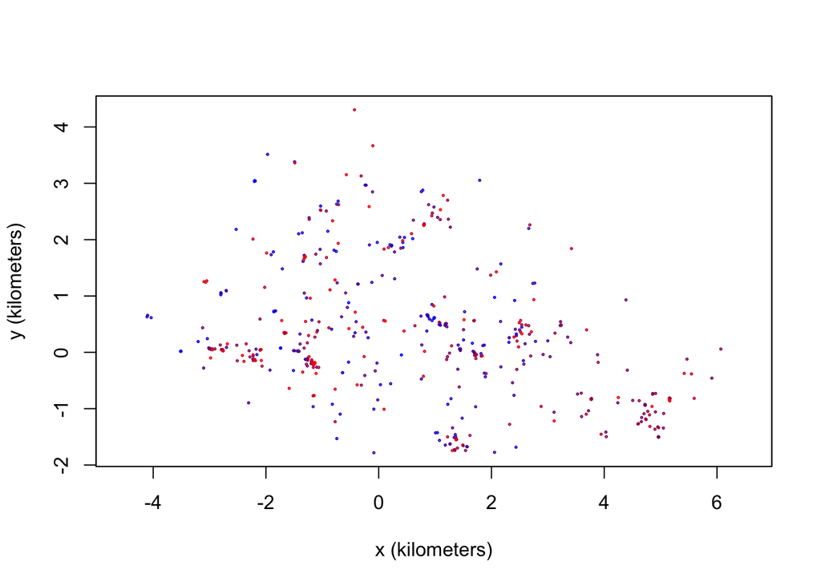

```r
# Load ctmm package
library(ctmm)

# Import maned wolf data
data(wolf)

# Subset to single individual
DATA <- wolf$Gamba
plot(DATA, col = color(DATA, by = "time"))  # color by time
```

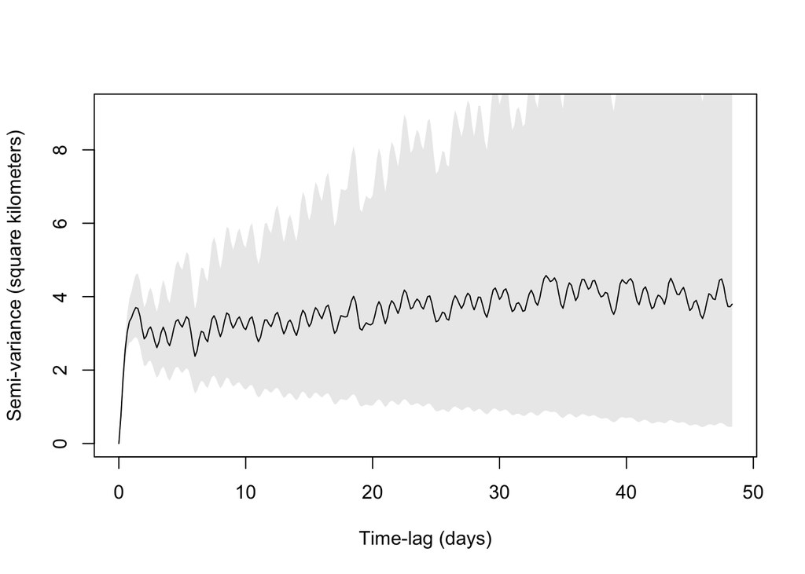

```r
# Calculate variogram
SVF <- variogram(DATA)
plot(SVF)
```

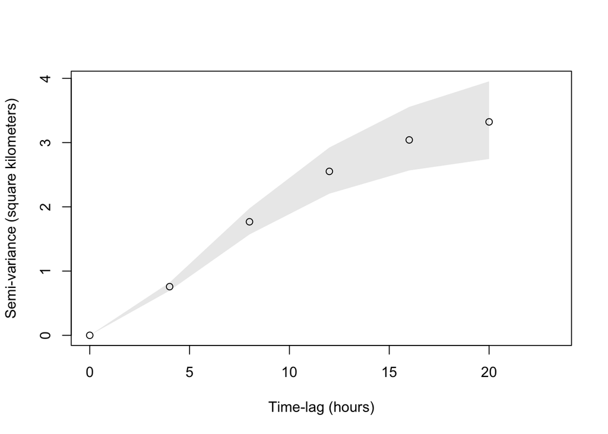

```r
plot(SVF, frac = 0.01)  # zoom in to first 20 hours
```

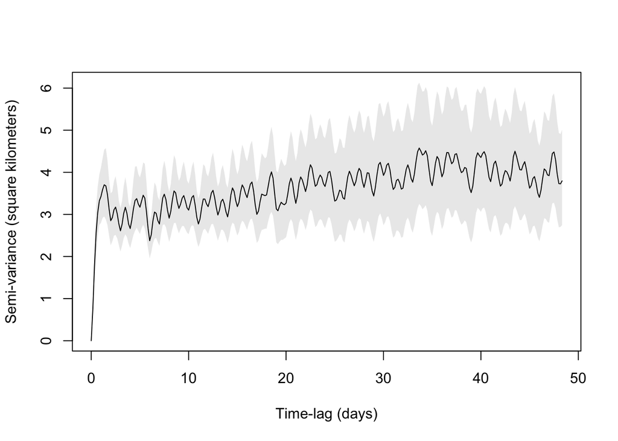

```r
# Calculate variogram with better confidence intervals
SVF <- variogram(DATA, CI = "Gauss")
plot(SVF)
```

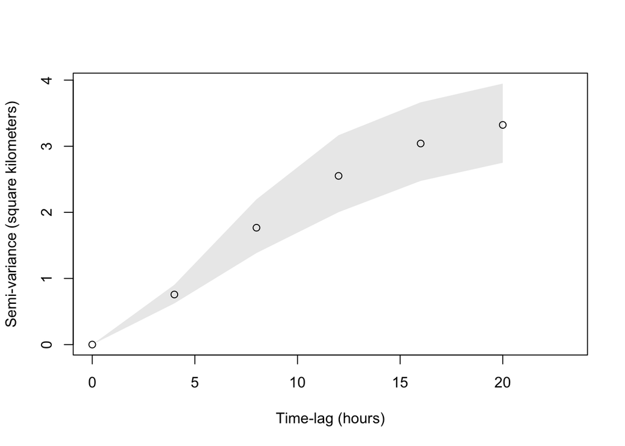

```r
plot(SVF, frac = 0.01)  # zoom in
```

Remember that there are other tools available for assessing and visualizing autocorrelation in your data. Keep in mind that some provide unbiased estimates of autocorrelation, while others are biased estimators.

```r
?acf  # or help(acf)
?correlogram  # or help(correlogram)
```

### 3.2 Model Selection

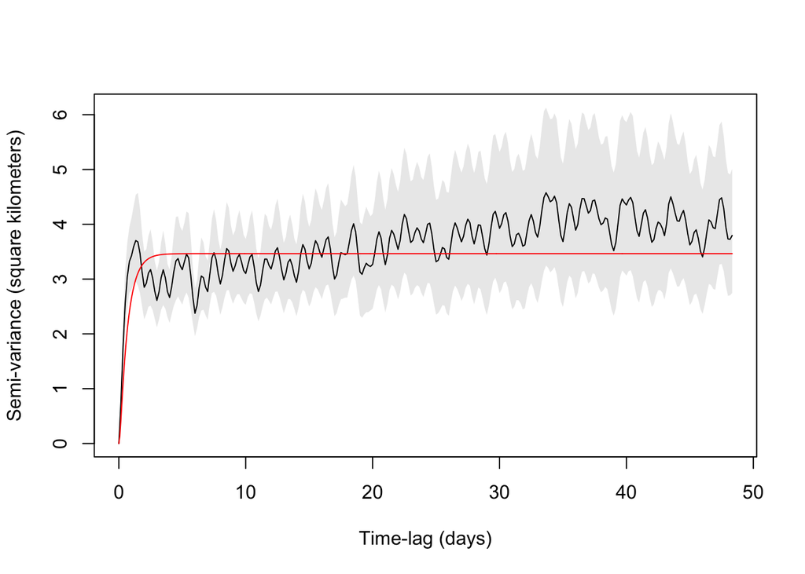

```r
# Guesstimate the autocorrelation parameters
# ctmm.guess(DATA, variogram = SVF)  # interactive mode
GUESS <- ctmm.guess(DATA, variogram = SVF, interactive = FALSE)  # non-interactive mode
plot(SVF, GUESS)  # inspect variogram and model guess parameters
```

```r
## Note the fluctuations in the autocorrelation

# Model selection
FITS <- ctmm.select(DATA, GUESS, verbose = TRUE, trace = FALSE)  # smaller data set (faster)
## verbose = TRUE to return all models

summary(FITS)  # OUF anisotropic model selected
```

```
##                       ΔAICc ΔRMSPE (m) DOF[area]
## OUF anisotropic   0.0000000   26.06649  205.5580
## OUf anisotropic   0.6815492    0.00000  233.3831
## OU anisotropic   69.8470969   46.27869  163.4149
## OUF             106.4875995  192.43595  196.4266
```

```r
# Let's look at the best-fit model
summary(FITS[[1]])
```

```
## $name
## [1] "OUF anisotropic"
##
## $DOF
##      mean      area diffusion     speed
##  131.1227  205.5580  291.8449  233.4881
##
## $CI
##                                         low       est      high
## area (square kilometers)          45.017082 51.865358 59.191429
## τ[position] (hours)                4.652191  6.636069  9.465953
## τ[velocity] (hours)                1.514738  2.239478  3.310976
## speed (kilometers/day)            14.415703 15.403676 16.390802
## diffusion (square kilometers/day) 11.300569 12.717983 14.217927
```

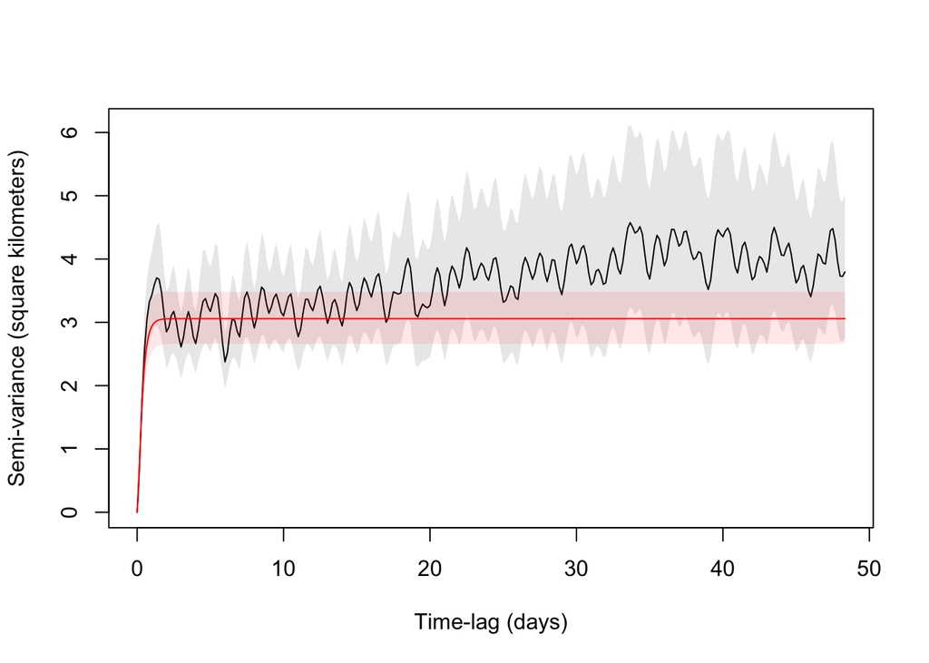

```r
plot(SVF, CTMM = FITS[[1]])  # variogram with best-fit model
```

```r
# Other models
summary(FITS[[2]])
```

```
## $name
## [1] "OUf anisotropic"
##
## $DOF
##      mean      area diffusion     speed
##  149.1625  233.3831  458.0042  339.8386
##
## $CI
##                                         low       est      high
## area (square kilometers)          44.497191 50.806945 57.528959
## τ (hours)                          3.620241  3.895816  4.192367
## speed (kilometers/day)            14.284669 15.086772 15.888300
## diffusion (square kilometers/day) 12.366506 13.582067 14.853794
```

```r
summary(FITS[[3]])
```

```
## $name
## [1] "OU anisotropic"
##
## $DOF
##      mean      area diffusion     speed
##  88.86911 163.41492 329.75121   0.00000
##
## $CI
##                                        low      est     high
## area (square kilometers)          43.86546 51.45180 59.63431
## τ[position] (hours)               10.83482 13.07415 15.77630
## diffusion (square kilometers/day) 10.17437 11.36843 12.62778
```

### 3.3 Preliminary Home-Range Estimation

`fast = FALSE` uses exact time spacing and has a computational cost as low as $O(n^2)$, including $O(n^2)$ function evaluations. With `PC="direct"` this method will produce a result that is exact to within machine precision, but with a computational cost of $O(n^3)$. `fast = FALSE, PC = 'direct'` is often the fastest method with small datasets, like here with this maned wolf.

```r
# Home range estimate (AKDE)
UD <- akde(DATA, FITS[[1]], weights = TRUE, PC = "direct", fast = FALSE, trace = FALSE)
```

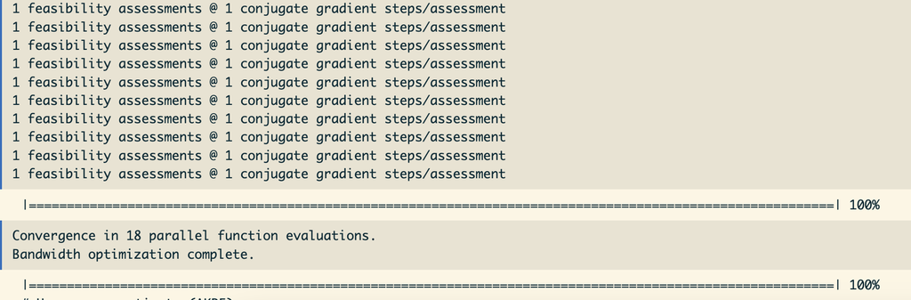

Example message output when running `akde` using bandwidth arguments `PC = "direct", fast = FALSE` for small data datasets. To see the output messages reporting convergence progress, set the trace argument to the desired amount of detail (ranging FALSE/0 to 3). The example above is for `trace = 2`.

```
## DOP values missing. Assuming DOP=1.
```

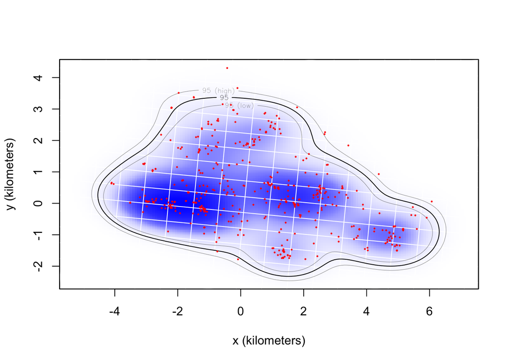

```r
# Plot home range estimate with data
plot(DATA, UD)
```

```
## DOP values missing. Assuming DOP=1.
```

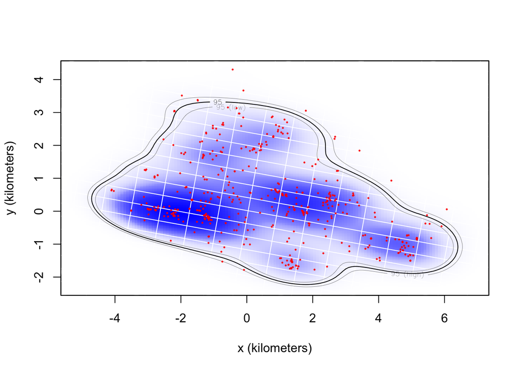

```r
# Compare to IID model (assumes independence)
FITS$IID <- ctmm.fit(DATA)

# Regular KDE
UD.IID <- akde(DATA, FITS$IID)  # NOT accounting for autocorrelation
plot(DATA, UD.IID)
```

```r
# Compare both models
summary(UD)  # much smaller ESS
```

```
## $DOF
##      area bandwidth
##   205.558   427.283
##
## $CI
##                               low      est     high
## area (square kilometers) 33.12317 38.16207 43.55253
##
## attr(,"class")
## [1] "area"
```

```r
summary(UD.IID)  # underestimates home range area
```

```
## $DOF
##      area bandwidth
##       561       562
##
## $CI
##                               low      est     high
## area (square kilometers) 33.62138 36.58668 39.67551
##
## attr(,"class")
## [1] "area"
```

## 4 Periodogram

Here, we formally introduce the Lomb-Scargle periodogram (`periodogram`), which will help us plot the data in a way that makes periodic patterns apparent. Periodograms decompose the animal location data signal to determine which frequency or frequencies contribute most to the signal. There is an existing vignette available for this function and several papers about [the method](https://doi.org/10.1186/s40462-016-0084-7), as well as [case studies](https://doi.org/10.1002/ecm.1260).

```r
vignette("periodogram")
```

The periodogram transforms telemetry data to be able to visualize it as the log(spectral density) as a function of the period (e.g., hourly, daily, monthly, yearly, etc.). There are various arguments in the function that can be used to adjust the algorithm for the data as needed.

There are two algorithms that can be used. Set `fast = FALSE` to revert to Scargle’s original (slower) algorithm, which involves fewer numerical approximations and is more exact (see Scargle, 1982). The `fast = TRUE` option uses the much faster FFT-based algorithm, which is better suited for longer datasets, and if `fast = 2`, the FFT algorithm will be used while sampling a highly composite number of times to increase power (see [Péron et al., 2016](https://doi.org/10.1186/s40462-016-0084-7)). The `res.time` argument is used to increase the resolution of the temporal grid when the FFT-based algorithm is used (`fast = TRUE` or `fast = 2`). By default, `res.time = 1`, so the algorithm defaults to adequate resolution for regularly scheduled data (even sampling, while permitting gaps). However, variable sampling rates require `res.time > 1` to resolve the fine-scale spectrum correctly. For the maned wolf data, we will use Scargle’s more exact algorithm, while inflating both the frequency and temporal resolution by a multiplier of 2.

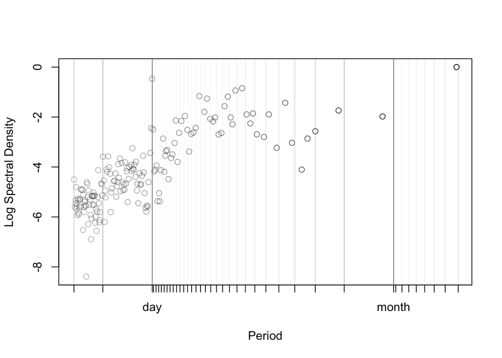

```r
# Calculate Lomb-Scargle periodogram (log spectral density)
LSP <- periodogram(DATA, fast = FALSE, res.time = 2, res.freq = 2)

# Visualize periodic patterns in autocorrelation
plot(LSP, max = TRUE)  # note the spike at the per day mark
```

The `max = TRUE` option above keeps only local maxima and often yields periodograms that are easier to interpret, especially when the resolution of the periodogram has been increased from the default. Important natural periods like the **stellar day**, **synodic month** (full moon phase cycle), and **tropical year** are labeled on the horizontal axes and given dark vertical lines in the plot. **Harmonics** of these natural periods have unlabeled tick marks on the horizontal axis and are are given lighter vertical lines in the plot. The two tick marks under a day represent the *second* and *third* harmonic of the day, or (24/2) 12 hours and (24/3) 8 hours, respectively.

When interpreting the periodogram, look for peaks in the spectral density that could represent a regular pattern in the data at that respective period (x-axis). For example, if an individual patrols a part of their home range each day, we would find a peak at the “day” mark. Peaks at the harmonics of a period indicate that fine details of the periodicity are resolved by the data. To visually assess significance, peaks should be compared to the normal variation around the smooth trend of the periodogram.

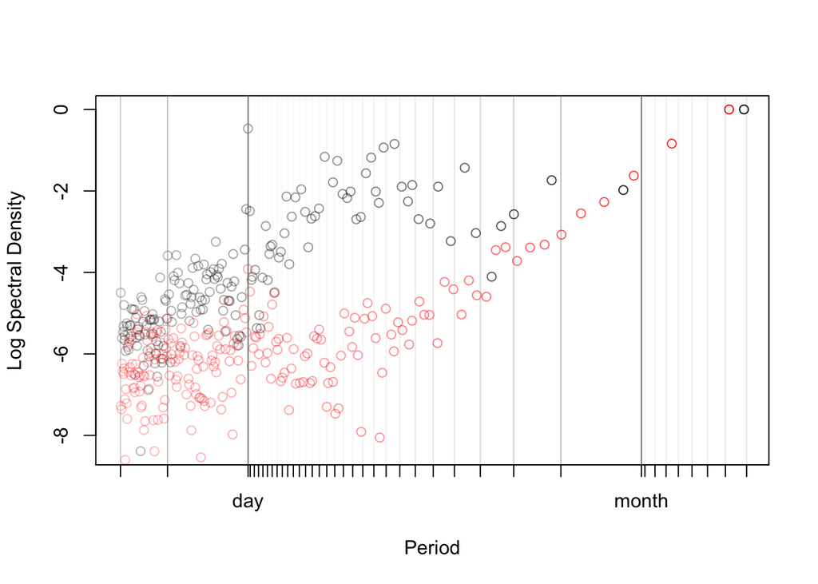

```r
# Compare with the sampling schedule
plot(LSP, diagnostic = TRUE, max = TRUE)
```

```r
## diagnostic = TRUE plots sampling schedule to help check for artifacts
## max = TRUE plots the local maxima of the periodogram (use only for res > 1)
```

> NOTE: The structure of the sampling schedule may introduce **artifacts** that appear as periodicity. To help determine whether periodogram peaks are representative of a biological process or one that is driven by sampling, we can overlay the periodogram of both and compare.

Be careful when comparing periodograms across individuals, especially if the aperiodic stochastic movements of these individuals are not the same. Overall, the periodograms is a great, nonparametric tool for exploring patterns in your data, but they may not be able to detect everything. If we do detect potential periodicity, we can switch to a parametric approach to model it by including a parameter for the period. This approach also allows us to model a circulatory process (stochastic component), which is often difficult to identify in the periodogram.

## 5 Fitting a Periodic Movement Model

Once we have determined that there is periodicity in the animal’s movement and space use, we can incorporate this into our autocorrelation models to better fit the variogram. We will use the `ctmm` function, which can set specific parameters for the movement models, to allow a:

- **Periodic-mean process:** The mean will follow an oscillatory pattern in the autocorrelation model fit to the variogram. This would represent how an animal reverts to a point that moves periodically through time. Set `mean = "periodic"`.
  - You need to specify one or more period values that you want `ctmm` to consider (`period` argument).
- **Circulation process:** The stochastic (random) component of periodicity that includes a rotational effect. Set `circle = TRUE`.

Since our periodogram showed a peak at the 1 day mark, let’s include this in the period, as well as 1 month. These parameters can then be fed into our initial guesses for parameter values through the `CTMM` argument in `ctmm.guess`.

```r
# Add periodic parameter to model
PROTO <- ctmm(mean = "periodic", period = c(24 %#% "hours", 1 %#% "month"),
              circle = TRUE)
GUESS <- ctmm.guess(DATA, variogram = SVF, CTMM = PROTO, interactive = FALSE)
## Guesstimate with the added periodicity and stochastic circulation parameters
```

```r
# Periodic movement model selection
PFITS <- ctmm.select(DATA, GUESS, verbose = TRUE, trace = 2)  # return all models
## checks for harmonics
save(PFITS, file = "Data/wolf_periodic.rda")
```

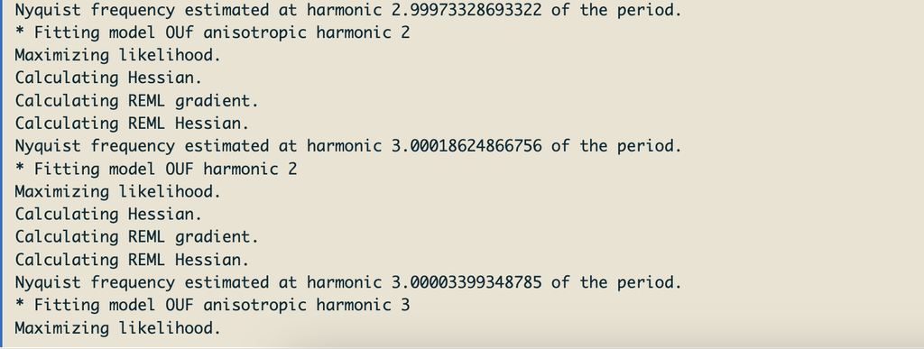

Example message output when running `ctmm.select` while estimating a parameter for movement periodicity. Note the parameters being estimated for the model at different harmonics.

```r
# Load saved model selection results
load(file = "Data/wolf_periodic.rda")

# Model selection results
summary(PFITS)
```

[output not shown]

The summary lists the tested models from best-fit to worst-fit. Note that we sort our models differently here (not just by $\Delta$AICc. For a given movement model (e.g., OUF anisotropic), the different non-stationary models (for the harmonics) are sorted by the mean square predictive error (MSPE), not AICc (information criterion). This is because likelihood-based model selection *can* badly overfit with these types of models. For sorting between the movement models (e.g., between OUF anisotropic and OU anisotropic), the information criterion (AICc) is used.

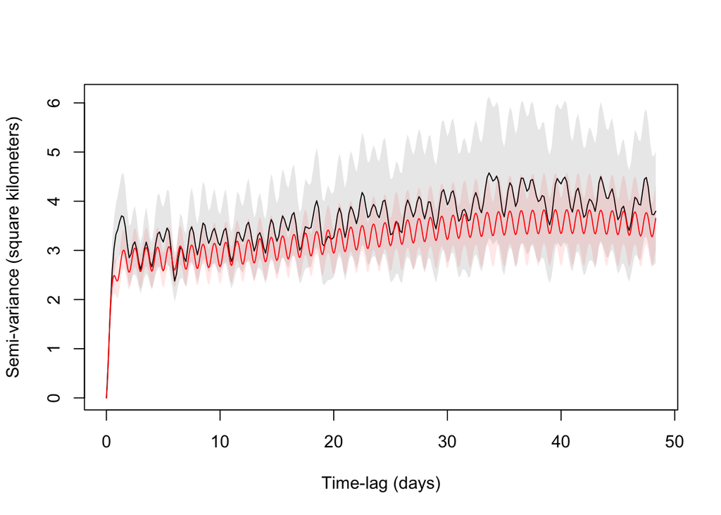

```r
# How do the models fit to the variogram?
plot(SVF, CTMM = PFITS[[1]])  # best-fit model
```

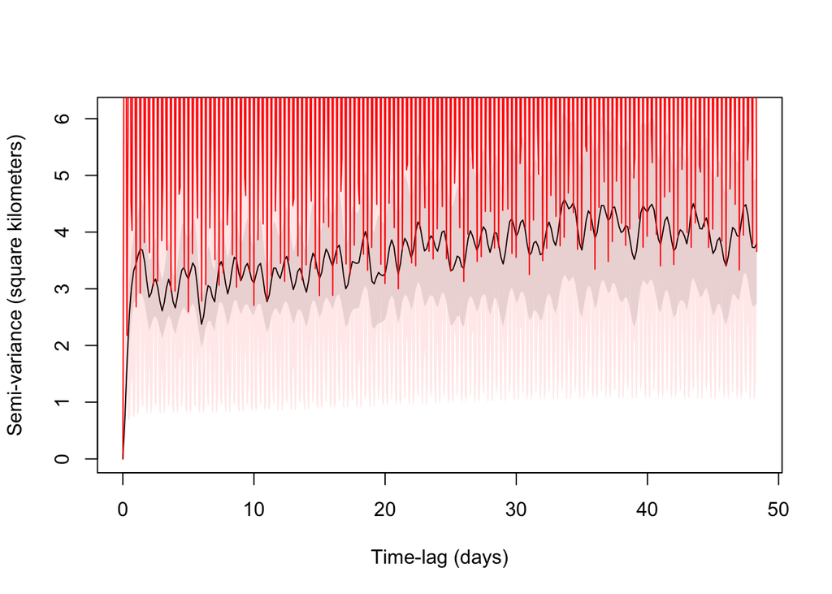

```r
plot(SVF, CTMM = PFITS[[9]])  # OUF anisotropic harmonic 3 1 (poorer fit)
```

```r
# Selected model
summary(PFITS[[1]])  # OUF anisotropic harmonic 2 1
```

```
## $name
## [1] "OUF anisotropic harmonic 2 1"
##
## $DOF
##      mean      area diffusion     speed
##  113.9082  191.1579  309.9059  163.5778
##
## $CI
##                                          low       est      high
## period.1 (days)                    0.9993359  1.000022  1.000709
## period.2 (months)                  2.0976521  2.732749  3.560130
## rotation/deviation %              35.8316849 45.004473 53.716403
## rotation/speed %                  25.2774187 30.358554 35.347202
## area (square kilometers)          38.1629609 44.208034 50.691027
## τ[position] (hours)                6.2174048  8.178708 10.758712
## τ[velocity] (hours)                1.1119619  1.584862  2.258880
## speed (kilometers/day)            14.6150188 15.827793 17.039341
## diffusion (square kilometers/day)  9.0138296 10.108004 11.263950
```

```r
## Periodic pattern of space use at 1-day mark (daily periodic pattern in movement)
```

- **rotation/deviation %:** The proportion of the variance in the animal’s **location** that is caused by the periodicity in the mean.
- **rotation/speed %:** The proportion of the variance in the animal’s **velocity** that is caused by the periodicity in the mean.
- **circulation period:** The period of the stochastic circulations. On average, what is the period of time (number of months, days, or hours) the animal takes to re-pass through the same areas.

```
## DOP values missing. Assuming DOP=1.
```

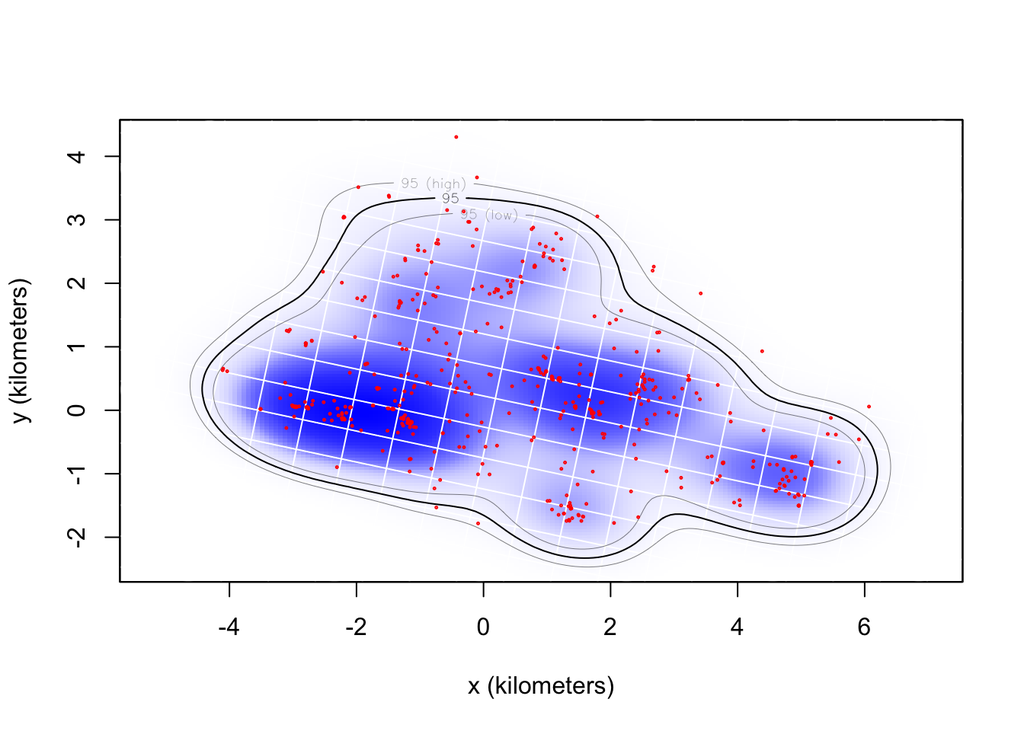

```r
# Re-fit AKDE for home range
UD_period <- akde(DATA, PFITS[[1]], weights = TRUE,
                  PC = "direct", fast = FALSE, trace = FALSE)

plot(DATA, CTMM = UD_period)
```

```r
## Fairly small difference in the home range
## Would have been hard to notice the periodicity without the periodogram
```

Note that there is very little change in the home range estimate in this case. It would have been difficult to identify the daily patterns in space use without checking the periodogram, as they are not obvious in the raw tracking data. Péron et al. (2016) determined that all 8 individual maned wolves in the full data set patrol their home ranges along daily-repeated routes, a pattern that was otherwise masked by aperiodic stochastic movement.

## 6 Key functions reference

[output not shown]

*Next: **Module 4 Part b — Encounter/Interaction Analysis** — We examine methods for investigating potential interactions and encounters between individuals in a population (or across species).*